# Assignment 7: Visualization - Some aspects of ggplot2

### I. Questions on Your Selected Data

Use the data of your own. Produce the following types of plots and comment on each plot. Plots should be meaningful. If you use the data we used in class, make sure the plots are not the same as the ones in the slides. All plots should have title, caption, appropriate labels on x and y-axis.

### Loading the data

My data is a student performance data set

```r
library(tidyverse)
df <- read_delim('C:/Users/student/Documents/R/Math421/student-mat.csv', delim =';')
```

1. Make a plot using `face_wrap` by one categorical variable (`face_wrap(~variable1)`)

```r
head(df)
```

```
## # A tibble: 6 x 33
##   school sex     age address famsize Pstatus  Medu  Fedu Mjob     Fjob     reason
##   <chr>  <chr> <dbl> <chr>   <chr>   <chr>   <dbl> <dbl> <chr>    <chr>    <chr>
## 1 GP     F        18 U       GT3     A           4     4 at_home  teacher  course
## 2 GP     F        17 U       GT3     T           1     1 at_home  other    course
## 3 GP     F        15 U       LE3     T           1     1 at_home  other    other
## 4 GP     F        15 U       GT3     T           4     2 health   services home
## 5 GP     F        16 U       GT3     T           3     3 other    other    home
## 6 GP     M        16 U       LE3     T           4     3 services other    reput~
## # ... with 22 more variables: guardian <chr>, traveltime <dbl>,
## #   studytime <dbl>, failures <dbl>, schoolsup <chr>, famsup <chr>, paid <chr>,
## #   activities <chr>, nursery <chr>, higher <chr>, internet <chr>,
## #   romantic <chr>, famrel <dbl>, freetime <dbl>, goout <dbl>, Dalc <dbl>,
## #   Walc <dbl>, health <dbl>, absences <dbl>, G1 <dbl>, G2 <dbl>, G3 <dbl>
```

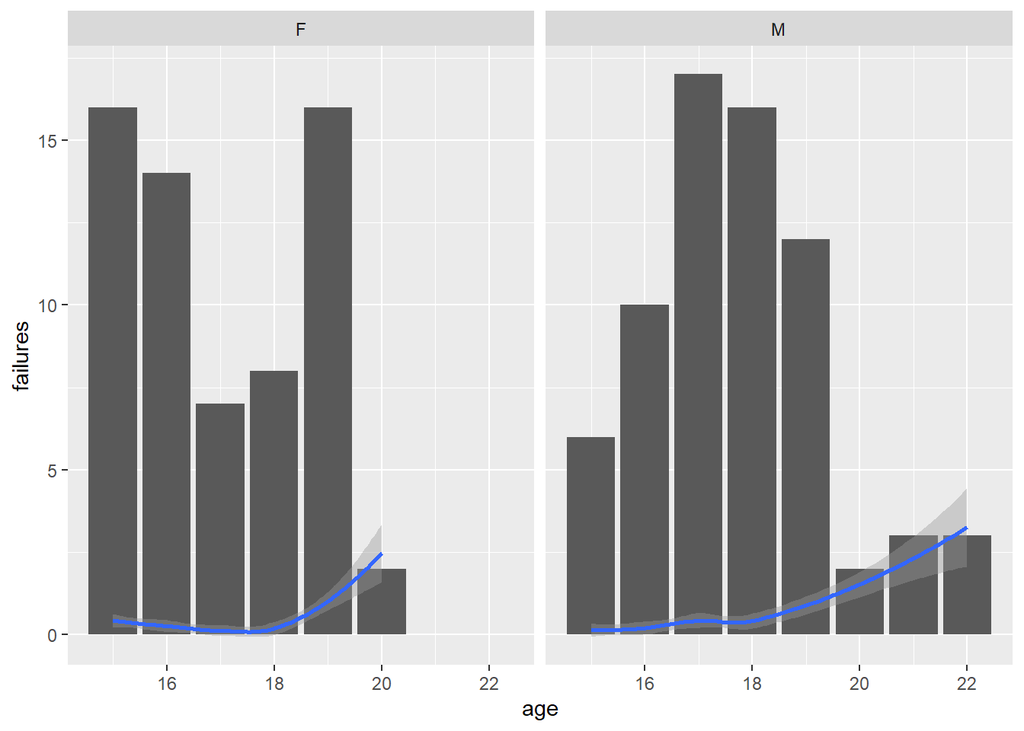

```r
df  %>%
  ggplot(mapping=aes(x=age, y=failures))+
  geom_col()+
  geom_smooth()+
  facet_wrap(~sex)
```

2. Make a plot using `face_wrap` by two categorical variables (`face_wrap(variable1~variable2)`)

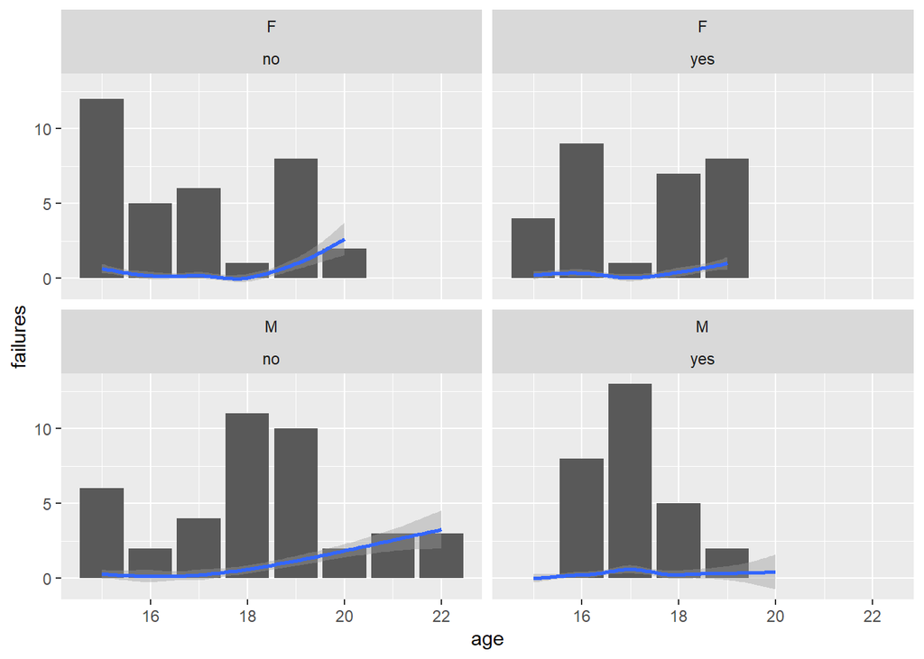

```r
df  %>%
  ggplot(mapping=aes(x=age, y=failures))+
  geom_col()+
  geom_smooth()+
  facet_wrap(~sex~activities)
```

3. Make a plot using `position ='jitter'`.

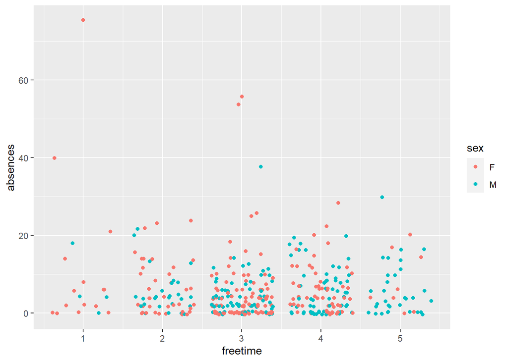

```r
df %>% ggplot()+
  geom_point(mapping=aes(x=freetime, y=absences, color=sex),
             position='jitter')
```

4. Make a plot using `position ='dodge'`.

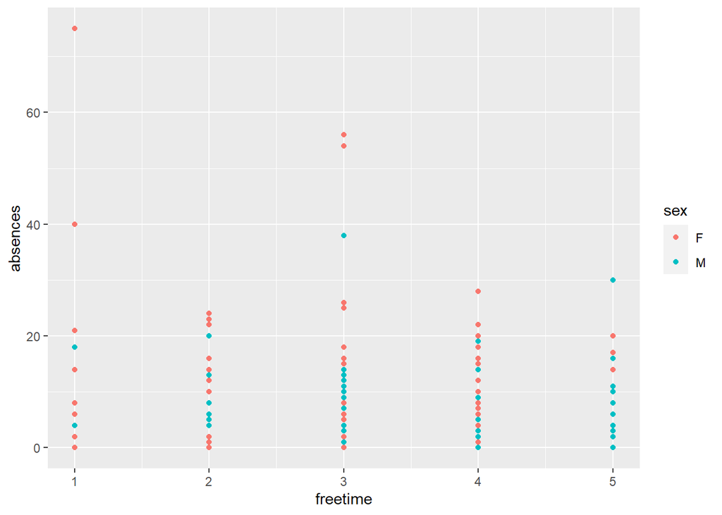

```r
df %>% ggplot()+
  geom_point(mapping=aes(x=freetime, y=absences, color=sex),
             position='dodge')
```

5. Make a plot using `position ='fill'`.

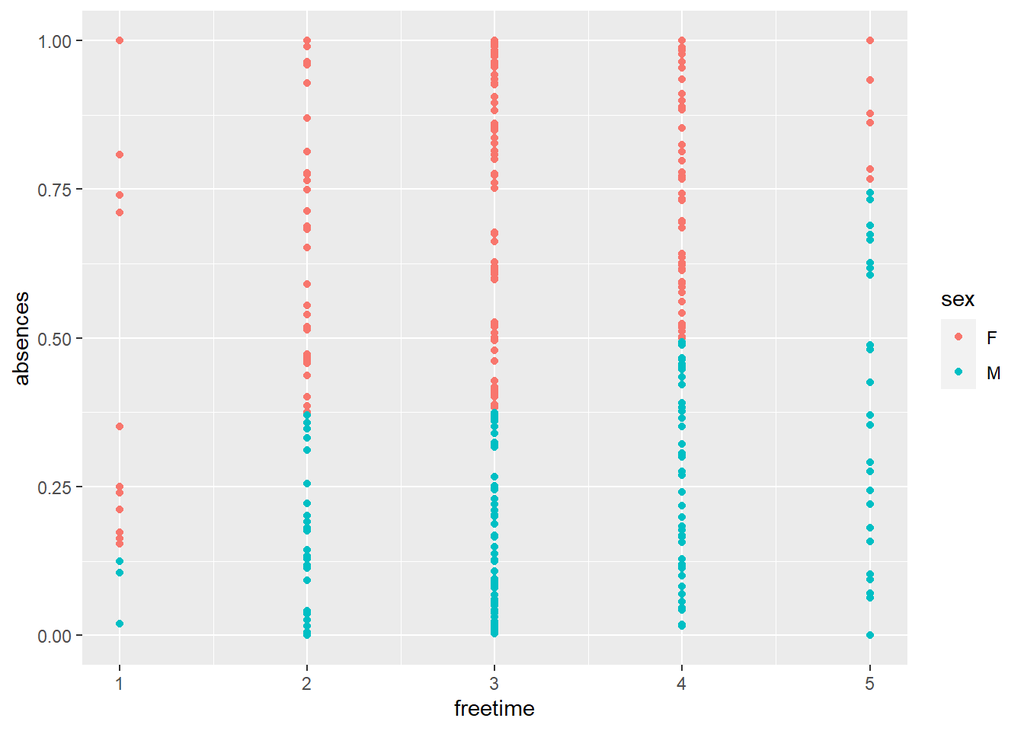

```r
df %>% ggplot()+
  geom_point(mapping=aes(x=freetime, y=absences, color=sex),
             position='fill')
```

6. Make a plot using `geom_col`.

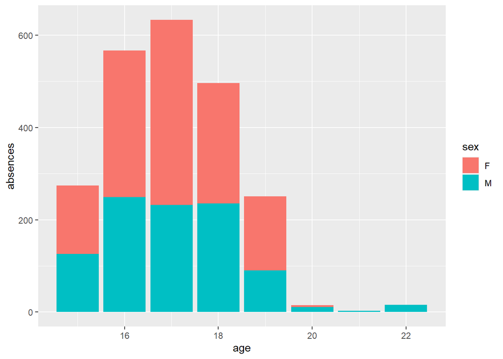

```r
df %>% ggplot()+
  geom_col(mapping=aes(x=age, y=absences, fill=sex),
             )
```

7. Change the theme of one of your plots.

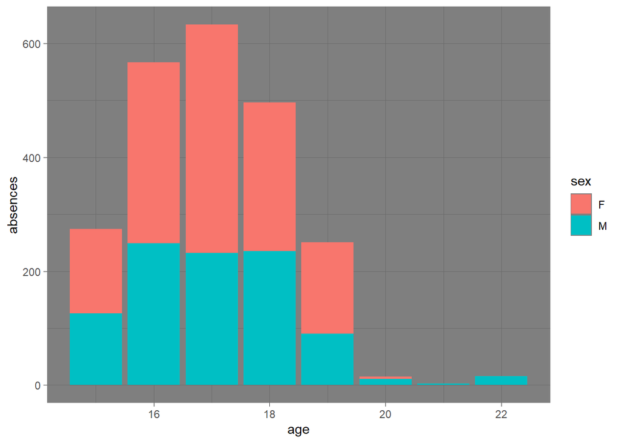

```r
df %>% ggplot()+
  geom_col(mapping=aes(x=age, y=absences, fill=sex)) + theme_dark()
```

```r
gg <- df  %>%
  ggplot(mapping=aes(x=age, y=failures))+
  geom_col()+
  geom_smooth()+
  facet_wrap(~sex)
ggsave(filename = 'abc.png', plot = gg)
```